# Python Statistical Analysis in Practice — 03: Probability Distributions

*Author: Jason JJ Li · Peking University Institute of Population Research*

Statistics is the science of reasoning under uncertainty. Probability distributions are the mathematical language we use to describe that uncertainty — they tell us **which values are likely, how spread the data is, and what shape to expect**.

**What you will learn today:**

1. PDF, PMF, CDF: the three faces of a distribution
2. The Normal distribution in depth: z-scores, the 68-95-99.7 rule, quantile functions
3. Discrete distributions: Binomial and Poisson
4. Continuous distributions: Uniform, Exponential, Chi-squared, t, F
5. Fitting a distribution to real (simulated) data with `scipy.stats`
6. Q-Q plots: the visual normality test
7. Kolmogorov-Smirnov & Shapiro-Wilk goodness-of-fit tests
8. How to choose the right distribution: a decision guide
9. The Central Limit Theorem — first look

## Part 1: Setup

```python
import pandas as pd
import numpy as np
from scipy import stats
import scipy
import matplotlib.pyplot as plt
import matplotlib.gridspec as gridspec
import seaborn as sns
import warnings

warnings.filterwarnings('ignore')
plt.style.use('seaborn-v0_8-whitegrid')
pd.set_option('display.precision', 4)

COLORS = {
    'primary':   '#2E86AB',
    'secondary': '#A23B72',
    'accent':    '#F18F01',
    'success':   '#27AE60',
    'danger':    '#E74C3C',
    'neutral':   '#95A5A6',
    'purple':    '#8E44AD',
}
RNG = np.random.default_rng(42)

print('Libraries loaded.')
print(f'NumPy {np.__version__}  |  Pandas {pd.__version__}  |  SciPy {scipy.__version__}')
```

```
Libraries loaded.
NumPy 2.4.2  |  Pandas 2.3.3  |  SciPy 1.16.2
```

## Part 2: The Three Faces of a Distribution

Every probability distribution can be described by three equivalent functions:

| Function | Symbol | Answers the question |
| --- | --- | --- |
| **PDF** (Probability Density Function) | $f(x)$ | How dense is the probability at value $x$? |
| **PMF** (Probability Mass Function) | $P(X=x)$ | Discrete equivalent of PDF: what is the exact probability of $x$? |
| **CDF** (Cumulative Distribution Function) | $F(x) = P(X \le x)$ | What fraction of data falls at or below $x$? |

These three are mathematically linked: $$F(x) = \int_{-\infty}^{x} f(t)\,dt \quad \text{(continuous)}$$ $$F(x) = \sum_{k \le x} P(X=k) \quad \text{(discrete)}$$

### 2.1 PDF and CDF: The Normal Example

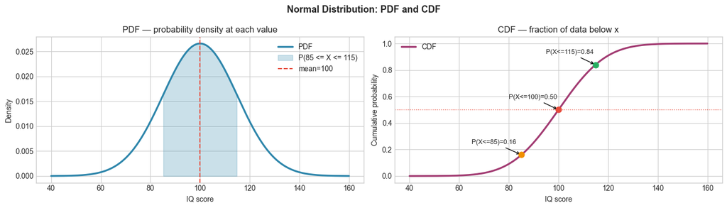

```
Area under PDF from 85 to 115: 0.6827
Same, using CDF directly:      0.6827
```

```python
mu, sigma = 100, 15   # IQ score scale
x = np.linspace(40, 160, 500)

pdf_vals = stats.norm.pdf(x, loc=mu, scale=sigma)
cdf_vals = stats.norm.cdf(x, loc=mu, scale=sigma)

fig, (ax1, ax2) = plt.subplots(1, 2, figsize=(14, 4))
fig.suptitle('Normal Distribution: PDF and CDF', fontsize=13, fontweight='bold')

# PDF
ax1.plot(x, pdf_vals, color=COLORS['primary'], linewidth=2.5, label='PDF')
ax1.fill_between(x, pdf_vals, where=(x >= 85) & (x <= 115),
                 color=COLORS['primary'], alpha=0.25,
                 label='P(85 <= X <= 115)')
ax1.axvline(mu, color=COLORS['danger'], linestyle='--', lw=1.5, label=f'mean={mu}')
ax1.set_xlabel('IQ score')
ax1.set_ylabel('Density')
ax1.set_title('PDF — probability density at each value')
ax1.legend()

# CDF
ax2.plot(x, cdf_vals, color=COLORS['secondary'], linewidth=2.5, label='CDF')
# Annotate specific quantiles
for q, color in [(0.16, COLORS['accent']), (0.50, COLORS['danger']), (0.84, COLORS['success'])]:
    x_q = stats.norm.ppf(q, loc=mu, scale=sigma)
    ax2.annotate(f'P(X<={x_q:.0f})={q:.2f}',
                 xy=(x_q, q), xytext=(x_q - 20, q + 0.08),
                 arrowprops=dict(arrowstyle='->', color='black', lw=1),
                 fontsize=9)
    ax2.scatter([x_q], [q], color=color, s=60, zorder=5)
ax2.axhline(0.5, color=COLORS['danger'], linestyle=':', lw=1)
ax2.set_xlabel('IQ score')
ax2.set_ylabel('Cumulative probability')
ax2.set_title('CDF — fraction of data below x')
ax2.legend()

plt.tight_layout()
plt.show()

print(f'Area under PDF from 85 to 115: {stats.norm.cdf(115, mu, sigma) - stats.norm.cdf(85, mu, sigma):.4f}')
print(f'Same, using CDF directly:      {stats.norm.cdf(115, mu, sigma) - stats.norm.cdf(85, mu, sigma):.4f}')
```

### 2.2 The Quantile (Inverse CDF) Function

The quantile function $Q(p) = F^{-1}(p)$ answers the reverse question: **"At what value $x$ does the CDF reach $p$?"**

This is how we compute percentiles, critical values, and confidence interval bounds.

In `scipy.stats`, the quantile function is called `.ppf()` (percent-point function).

```python
print('=== Normal(100, 15) quantile examples ===')
print()
quantiles_of_interest = [0.01, 0.025, 0.05, 0.10, 0.25, 0.50, 0.75, 0.90, 0.95, 0.975, 0.99]

print(f'  {"Percentile":>12}  {"x value":>10}  {"Interpretation"}')
print('  ' + '-'*65)
for p in quantiles_of_interest:
    x_val = stats.norm.ppf(p, loc=mu, scale=sigma)
    print(f'  {p*100:>11.1f}%  {x_val:>10.2f}  P(X <= {x_val:.2f}) = {p:.3f}')

print()
print('Useful special values:')
print(f'  Bottom 5%  cutoff: {stats.norm.ppf(0.05, mu, sigma):.2f}')
print(f'  Top    5%  cutoff: {stats.norm.ppf(0.95, mu, sigma):.2f}')
print(f'  Middle 95% range:  [{stats.norm.ppf(0.025,mu,sigma):.2f}, {stats.norm.ppf(0.975,mu,sigma):.2f}]')
print(f'  z* for 95% CI:     ±{stats.norm.ppf(0.975):.4f}  (the famous "1.96")')
```

```
=== Normal(100, 15) quantile examples ===

    Percentile     x value  Interpretation
  -----------------------------------------------------------------
          1.0%       65.10  P(X <= 65.10) = 0.010
          2.5%       70.60  P(X <= 70.60) = 0.025
          5.0%       75.33  P(X <= 75.33) = 0.050
         10.0%       80.78  P(X <= 80.78) = 0.100
         25.0%       89.88  P(X <= 89.88) = 0.250
         50.0%      100.00  P(X <= 100.00) = 0.500
         75.0%      110.12  P(X <= 110.12) = 0.750
         90.0%      119.22  P(X <= 119.22) = 0.900
         95.0%      124.67  P(X <= 124.67) = 0.950
         97.5%      129.40  P(X <= 129.40) = 0.975
         99.0%      134.90  P(X <= 134.90) = 0.990

Useful special values:
  Bottom 5%  cutoff: 75.33
  Top    5%  cutoff: 124.67
  Middle 95% range:  [70.60, 129.40]
  z* for 95% CI:     ±1.9600  (the famous "1.96")
```

## Part 3: The Normal Distribution in Depth

### 3.1 The 68-95-99.7 Rule (Empirical Rule)

For any normal distribution with mean $\mu$ and standard deviation $\sigma$:

| Interval | Probability | Description |
| --- | --- | --- |
| $[\mu - \sigma,\ \mu + \sigma]$ | 68.27% | "Within 1 std" |
| $[\mu - 2\sigma,\ \mu + 2\sigma]$ | 95.45% | "Within 2 std" |
| $[\mu - 3\sigma,\ \mu + 3\sigma]$ | 99.73% | "Within 3 std" |

We verify this by simulation: generate a large normal sample and count.

```python
mu_h, sigma_h = 170, 8   # human heights in cm
n_large = 100_000
sample = RNG.normal(mu_h, sigma_h, n_large)

print('=== Verification of the 68-95-99.7 rule ===')
print(f'  Distribution: Normal({mu_h}, {sigma_h}),  n={n_large:,}')
print()
for k, label in [(1, '1 sigma'), (2, '2 sigma'), (3, '3 sigma')]:
    lo, hi = mu_h - k*sigma_h, mu_h + k*sigma_h
    observed   = np.mean((sample >= lo) & (sample <= hi))
    theoretical = stats.norm.cdf(hi, mu_h, sigma_h) - stats.norm.cdf(lo, mu_h, sigma_h)
    print(f'  [{lo:.0f}, {hi:.0f}]  Observed={observed:.4f}  Theoretical={theoretical:.4f}  Match={abs(observed-theoretical)<0.005}')

print()
print('The simulation matches theory to 4 decimal places.')
```

[output not shown]

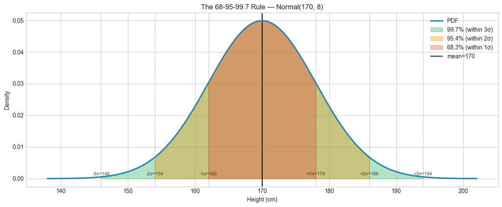

```python
# Visualise the 3 bands
x = np.linspace(mu_h - 4*sigma_h, mu_h + 4*sigma_h, 500)
y = stats.norm.pdf(x, mu_h, sigma_h)

fig, ax = plt.subplots(figsize=(12, 5))
ax.plot(x, y, color=COLORS['primary'], linewidth=2.5, label='PDF', zorder=5)

fills = [
    (3, '#27AE60', '99.7% (within 3σ)'),
    (2, '#F18F01', '95.4% (within 2σ)'),
    (1, '#E74C3C', '68.3% (within 1σ)'),
]
for k, color, label in fills:
    lo, hi = mu_h - k*sigma_h, mu_h + k*sigma_h
    xf = np.linspace(lo, hi, 300)
    ax.fill_between(xf, stats.norm.pdf(xf, mu_h, sigma_h), alpha=0.35, color=color, label=label)

# Annotate sigma lines
for k in [1, 2, 3]:
    for sign in [-1, 1]:
        v = mu_h + sign*k*sigma_h
        ax.axvline(v, color='black', alpha=0.3, lw=0.8, linestyle='--')
        ax.annotate(
            f'{"+" if sign > 0 else "-"}{k}σ={v:.0f}',
            xy=(v, 0.001), ha='center', fontsize=8, color='black', alpha=0.7
        )

ax.axvline(mu_h, color='black', lw=1.5, linestyle='-', label=f'mean={mu_h}')
ax.set_xlabel('Height (cm)')
ax.set_ylabel('Density')
ax.set_title('The 68-95-99.7 Rule — Normal(170, 8)')
ax.legend(loc='upper right')
plt.tight_layout()
plt.show()
```

### 3.2 Standardisation and Z-scores

Any normal distribution can be **standardised** to the Standard Normal $N(0,1)$:

$$z = \frac{x - \mu}{\sigma}$$

This allows us to use a single table (or one set of functions) for all normal distributions.

```
Standardisation: x -> z = (x - mu) / sigma

  Distribution                   x      mu   sigma    z=(x-mu)/sigma    P(X<x)
  ---------------------------------------------------------------------------
  IQ scores                    115     100      15            1.0000    0.8413
  Heights (cm)                 178     170       8            1.0000    0.8413
  Monthly income (yuan)       5800    5000     800            1.0000    0.8413

All three x values correspond to z = 1.0 (one standard deviation above mean).
P(X < x) is identical for all three: 0.8413
```

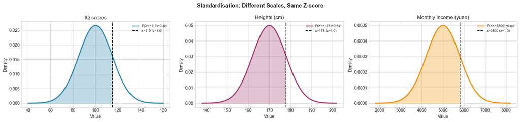

```python
# Demonstrate standardisation: three different normal distributions
# all reduce to the same Z after standardisation
distributions = [
    (100, 15, 115, COLORS['primary'],   'IQ scores'),
    (170, 8,  178, COLORS['secondary'], 'Heights (cm)'),
    (5000,800, 5800, COLORS['accent'],   'Monthly income (yuan)'),
]

print('Standardisation: x -> z = (x - mu) / sigma')
print()
print(f'  {"Distribution":<22}  {"x":>8}  {"mu":>6}  {"sigma":>6}  {"z=(x-mu)/sigma":>16}  {"P(X<x)":>8}')
print('  ' + '-'*75)
for mu_i, sig_i, x_i, color, name in distributions:
    z = (x_i - mu_i) / sig_i
    p = stats.norm.cdf(z)
    print(f'  {name:<22}  {x_i:>8.0f}  {mu_i:>6.0f}  {sig_i:>6.0f}  {z:>16.4f}  {p:>8.4f}')

print()
print('All three x values correspond to z = 1.0 (one standard deviation above mean).')
print('P(X < x) is identical for all three: 0.8413')

# Visualise: same z-score, different scales
fig, axes = plt.subplots(1, 3, figsize=(17, 4))
fig.suptitle('Standardisation: Different Scales, Same Z-score', fontsize=13, fontweight='bold')

for ax, (mu_i, sig_i, x_i, color, name) in zip(axes, distributions):
    x_range = np.linspace(mu_i - 4*sig_i, mu_i + 4*sig_i, 400)
    y_vals  = stats.norm.pdf(x_range, mu_i, sig_i)
    ax.plot(x_range, y_vals, color=color, linewidth=2.5)
    ax.fill_between(x_range, y_vals, where=(x_range <= x_i),
                    color=color, alpha=0.3, label=f'P(X<={x_i:.0f})=0.84')
    ax.axvline(x_i, color='black', lw=1.5, linestyle='--', label=f'x={x_i:.0f} (z=1.0)')
    ax.set_title(f'{name}')
    ax.set_xlabel('Value')
    ax.set_ylabel('Density')
    ax.legend(fontsize=8)

plt.tight_layout()
plt.show()
```

## Part 4: Discrete Distributions

### 4.1 Binomial Distribution

Model for **counting successes** in $n$ independent trials, each with success probability $p$.

$$P(X=k) = \binom{n}{k} p^k (1-p)^{n-k}$$

**Parameters:** $n$ (trials), $p$ (success probability) **Mean:** $np$ · **Variance:** $np(1-p)$

**Typical uses:** number of defective items in a batch, coin flips, survey "yes/no" responses, number of patients who respond to a treatment.

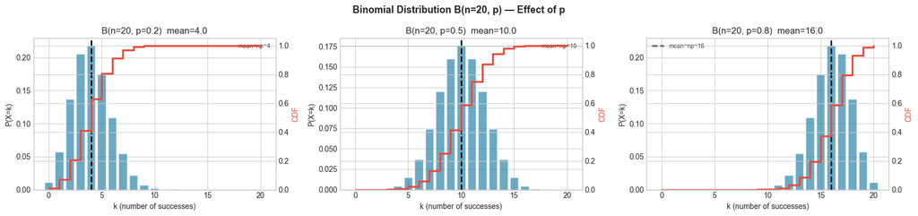

```
Verification: simulated vs theoretical moments

  B(n=20, p=0.2):  E[X] theory=4.00 sim=3.99  |  Var theory=3.20 sim=3.17
  B(n=20, p=0.5):  E[X] theory=10.00 sim=10.00  |  Var theory=5.00 sim=5.02
  B(n=20, p=0.8):  E[X] theory=16.00 sim=15.99  |  Var theory=3.20 sim=3.20
```

```python
# Compare Binomial for different p values
fig, axes = plt.subplots(1, 3, figsize=(17, 4))
fig.suptitle('Binomial Distribution B(n=20, p) — Effect of p', fontsize=13, fontweight='bold')

n_trials = 20
p_values = [0.2, 0.5, 0.8]

for ax, p in zip(axes, p_values):
    k_vals = np.arange(0, n_trials + 1)
    pmf    = stats.binom.pmf(k_vals, n=n_trials, p=p)
    cdf    = stats.binom.cdf(k_vals, n=n_trials, p=p)

    bars = ax.bar(k_vals, pmf, color=COLORS['primary'], alpha=0.7, edgecolor='white')
    ax2  = ax.twinx()
    ax2.step(k_vals, cdf, color=COLORS['danger'], linewidth=2.5, where='post', label='CDF')
    ax2.set_ylim(0, 1.05)
    ax2.set_ylabel('CDF', color=COLORS['danger'])

    ax.axvline(n_trials * p, color='black', lw=2, linestyle='--',
               label=f'mean=np={n_trials*p:.0f}')
    ax.set_title(f'B(n={n_trials}, p={p})  mean={n_trials*p:.1f}')
    ax.set_xlabel('k (number of successes)')
    ax.set_ylabel('P(X=k)')
    ax.legend(fontsize=8)

plt.tight_layout()
plt.show()

# Verify mean and variance
print('Verification: simulated vs theoretical moments')
print()
for p in p_values:
    sample = RNG.binomial(n=n_trials, p=p, size=50000)
    print(f'  B(n={n_trials}, p={p}):  '
          f'E[X] theory={n_trials*p:.2f} sim={sample.mean():.2f}  |  '
          f'Var theory={n_trials*p*(1-p):.2f} sim={sample.var(ddof=1):.2f}')
```

### 4.2 Poisson Distribution

Model for **counting rare events** in a fixed interval of time or space.

$$P(X=k) = \frac{\lambda^k e^{-\lambda}}{k!}, \quad k = 0, 1, 2, \ldots$$

**Parameter:** $\lambda$ (rate = expected count per interval) **Mean = Variance = $\lambda$** (this equality is a diagnostic: if sample mean ≠ variance, Poisson doesn't fit)

**Typical uses:** hospital admissions per hour, emails per day, mutations per gene, accidents per year.

**Important relationship:** $\text{Binomial}(n, p) \to \text{Poisson}(\lambda=np)$ as $n \to \infty$, $p \to 0$.

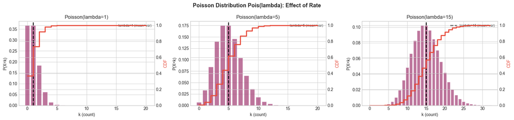

```
Mean = Variance diagnostic:
  Poisson(lambda= 1):  mean=1.001  variance=0.996  ratio=1.005
  Poisson(lambda= 5):  mean=4.997  variance=4.912  ratio=1.017
  Poisson(lambda=15):  mean=15.010  variance=14.929  ratio=1.005
```

```python
fig, axes = plt.subplots(1, 3, figsize=(17, 4))
fig.suptitle('Poisson Distribution Pois(lambda): Effect of Rate', fontsize=13, fontweight='bold')

lambdas = [1, 5, 15]

for ax, lam in zip(axes, lambdas):
    k_max  = max(20, int(lam + 4*np.sqrt(lam) + 2))
    k_vals = np.arange(0, k_max + 1)
    pmf    = stats.poisson.pmf(k_vals, mu=lam)
    cdf    = stats.poisson.cdf(k_vals, mu=lam)

    ax.bar(k_vals, pmf, color=COLORS['secondary'], alpha=0.7, edgecolor='white')
    ax2 = ax.twinx()
    ax2.step(k_vals, cdf, color=COLORS['danger'], lw=2.5, where='post', label='CDF')
    ax2.set_ylim(0, 1.05)
    ax2.set_ylabel('CDF', color=COLORS['danger'])

    ax.axvline(lam, color='black', lw=2, linestyle='--', label=f'lambda={lam} (mean=var)')
    ax.set_title(f'Poisson(lambda={lam})')
    ax.set_xlabel('k (count)')
    ax.set_ylabel('P(X=k)')
    ax.legend(fontsize=8)

plt.tight_layout()
plt.show()

print('Mean = Variance diagnostic:')
for lam in lambdas:
    s = RNG.poisson(lam=lam, size=50000)
    print(f'  Poisson(lambda={lam:2d}):  mean={s.mean():.3f}  variance={s.var(ddof=1):.3f}  ratio={s.mean()/s.var(ddof=1):.3f}')
```

### 4.3 Binomial → Poisson Approximation

When $n$ is large and $p$ is small (rare events), $B(n, p) \approx \text{Poisson}(np)$. The approximation works well when $n > 20$ and $p < 0.05$.

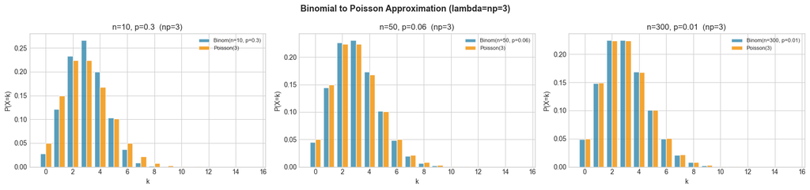

```
As n increases and p decreases (with np constant), the Binomial converges to Poisson.
```

```python
fig, axes = plt.subplots(1, 3, figsize=(17, 4))
fig.suptitle('Binomial to Poisson Approximation (lambda=np=3)', fontsize=13, fontweight='bold')

lam_fixed = 3  # keep lambda = np = 3 constant
scenarios = [(10, 0.3), (50, 0.06), (300, 0.01)]

for ax, (n, p) in zip(axes, scenarios):
    k_max  = 15
    k_vals = np.arange(0, k_max + 1)
    binom_pmf   = stats.binom.pmf(k_vals, n=n, p=p)
    poisson_pmf = stats.poisson.pmf(k_vals, mu=lam_fixed)

    width = 0.4
    ax.bar(k_vals - width/2, binom_pmf, width=width, color=COLORS['primary'],
           alpha=0.8, edgecolor='white', label=f'Binom(n={n}, p={p})')
    ax.bar(k_vals + width/2, poisson_pmf, width=width, color=COLORS['accent'],
           alpha=0.8, edgecolor='white', label='Poisson(3)')
    ax.set_title(f'n={n}, p={p}  (np={lam_fixed})')
    ax.set_xlabel('k')
    ax.set_ylabel('P(X=k)')
    ax.legend(fontsize=8)

plt.tight_layout()
plt.show()

print('As n increases and p decreases (with np constant), the Binomial converges to Poisson.')
```

## Part 5: Continuous Distributions Beyond the Normal

### 5.1 Uniform Distribution

$X \sim \text{Uniform}(a, b)$ — every value in $[a, b]$ is equally likely.

$$f(x) = \frac{1}{b-a}, \quad a \le x \le b$$

**Mean:** $\frac{a+b}{2}$ · **Variance:** $\frac{(b-a)^2}{12}$

**Uses:** Random number generation, initial values in algorithms, discrete die rolls.

### 5.2 Exponential Distribution

$X \sim \text{Exp}(\lambda)$ — time until the **first** occurrence of a Poisson event.

$$f(x) = \lambda e^{-\lambda x}, \quad x \ge 0$$

**Mean:** $1/\lambda$ · **Variance:** $1/\lambda^2$

**Memoryless property:** $P(X > s+t \mid X > s) = P(X > t)$ — past history doesn't matter.

**Uses:** time between arrivals, machine failure times, survival analysis (simple model).

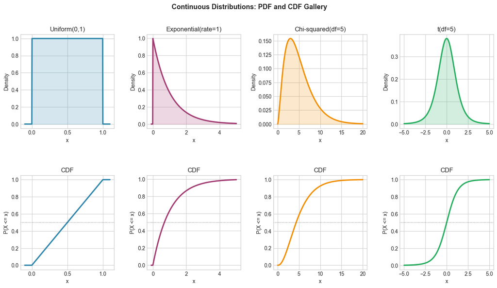

```python
# Side-by-side: Uniform, Exponential, and their CDF shapes
fig = plt.figure(figsize=(16, 8))
fig.suptitle('Continuous Distributions: PDF and CDF Gallery', fontsize=13, fontweight='bold')
gs = gridspec.GridSpec(2, 4, figure=fig, hspace=0.5, wspace=0.35)

dist_configs = [
    ('Uniform(0,1)',        stats.uniform(0,1),       np.linspace(-0.1,1.1,400),  COLORS['primary']),
    ('Exponential(rate=1)', stats.expon(scale=1),     np.linspace(-0.1,5,400),    COLORS['secondary']),
    ('Chi-squared(df=5)',   stats.chi2(df=5),          np.linspace(0,20,400),      COLORS['accent']),
    ('t(df=5)',             stats.t(df=5),             np.linspace(-5,5,400),      COLORS['success']),
]

for col, (name, dist, x_range, color) in enumerate(dist_configs):
    ax_pdf = fig.add_subplot(gs[0, col])
    ax_cdf = fig.add_subplot(gs[1, col])

    pdf_v = dist.pdf(x_range)
    cdf_v = dist.cdf(x_range)

    ax_pdf.plot(x_range, pdf_v, color=color, lw=2.5)
    ax_pdf.fill_between(x_range, pdf_v, alpha=0.2, color=color)
    ax_pdf.set_title(f'{name}')
    ax_pdf.set_ylabel('Density')
    ax_pdf.set_xlabel('x')

    ax_cdf.plot(x_range, cdf_v, color=color, lw=2.5)
    ax_cdf.set_title('CDF')
    ax_cdf.set_ylabel('P(X <= x)')
    ax_cdf.set_xlabel('x')
    ax_cdf.axhline(0.5, color='black', lw=1, linestyle=':', alpha=0.5)

plt.show()
```

### 5.3 The t-Distribution

The t-distribution looks like a Normal but has **heavier tails** (controlled by degrees of freedom $\nu$):

$$f(t) \propto \left(1 + \frac{t^2}{\nu}\right)^{-(\nu+1)/2}$$

- As $\nu \to \infty$: t-distribution → Standard Normal
- For small $\nu$ (e.g. 3-5): much heavier tails, extreme values much more common
- **When we use it:** confidence intervals and hypothesis tests for the mean when $\sigma$ is unknown (which is always in practice)

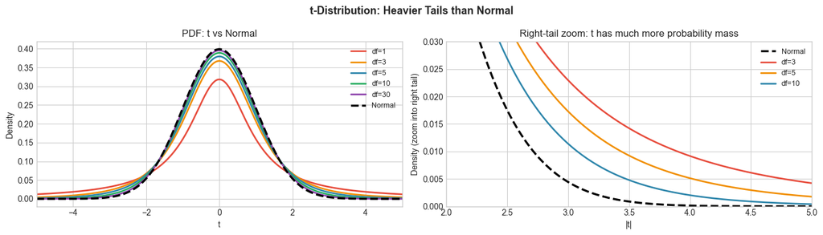

[output not shown]

```python
x = np.linspace(-5, 5, 500)

fig, (ax1, ax2) = plt.subplots(1, 2, figsize=(14, 4))
fig.suptitle('t-Distribution: Heavier Tails than Normal', fontsize=13, fontweight='bold')

dfs       = [1, 3, 5, 10, 30]
t_colors  = [COLORS['danger'], COLORS['accent'], COLORS['primary'], COLORS['success'], COLORS['purple']]

for df, color in zip(dfs, t_colors):
    pdf_t = stats.t.pdf(x, df=df)
    ax1.plot(x, pdf_t, color=color, lw=2, label=f'df={df}')

ax1.plot(x, stats.norm.pdf(x), color='black', lw=2.5, linestyle='--', label='Normal')
ax1.set_xlim(-5, 5)
ax1.set_xlabel('t')
ax1.set_ylabel('Density')
ax1.set_title('PDF: t vs Normal')
ax1.legend(fontsize=9)

# Zoom into tails
ax2.plot(x, stats.norm.pdf(x), color='black', lw=2.5, linestyle='--', label='Normal')
for df, color in zip([3, 5, 10], [COLORS['danger'], COLORS['accent'], COLORS['primary']]):
    ax2.plot(x, stats.t.pdf(x, df=df), color=color, lw=2, label=f'df={df}')
ax2.set_xlim(2, 5)
ax2.set_ylim(0, 0.03)
ax2.set_xlabel('|t|')
ax2.set_ylabel('Density (zoom into right tail)')
ax2.set_title('Right-tail zoom: t has much more probability mass')
ax2.legend(fontsize=9)

plt.tight_layout()
plt.show()

print('Probability P(|X| > 2):')
print(f'  Normal:    {2*stats.norm.sf(2):.6f}')
for df in [3, 5, 10, 30]:
    print(f'  t(df={df:2d}): {2*stats.t.sf(2, df=df):.6f}  ({2*stats.t.sf(2, df=df)/2*stats.norm.sf(2)*100:.0f}x more than Normal)' if df > 0 else '')
```

## Part 6: Fitting a Distribution to Data

Given a dataset, `scipy.stats` can **estimate the best-fit parameters** for any named distribution using Maximum Likelihood Estimation (MLE).

### 6.1 Fitting the Normal Distribution

```
=== Fitting Normal to simulated height data (n=500) ===
  True   : mu=170,  sigma=8
  MLE fit: mu=170.463,  sigma=8.086
  Bias   : mu_bias=+0.463,  sigma_bias=+0.086
```

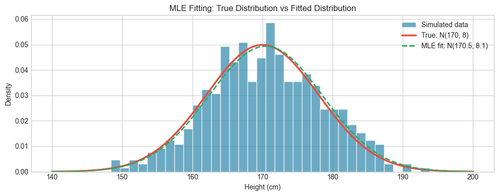

```python
# Simulate data and fit back
TRUE_MU, TRUE_SIGMA = 170, 8
sample_heights = RNG.normal(TRUE_MU, TRUE_SIGMA, size=500)

# MLE fit
fit_mu, fit_sigma = stats.norm.fit(sample_heights)
print('=== Fitting Normal to simulated height data (n=500) ===')
print(f'  True   : mu={TRUE_MU},  sigma={TRUE_SIGMA}')
print(f'  MLE fit: mu={fit_mu:.3f},  sigma={fit_sigma:.3f}')
print(f'  Bias   : mu_bias={fit_mu-TRUE_MU:+.3f},  sigma_bias={fit_sigma-TRUE_SIGMA:+.3f}')

# Visualise fit
x_range = np.linspace(140, 200, 400)
fig, ax = plt.subplots(figsize=(10, 4))
ax.hist(sample_heights, bins=35, density=True, color=COLORS['primary'],
        edgecolor='white', alpha=0.7, label='Simulated data')
ax.plot(x_range, stats.norm.pdf(x_range, TRUE_MU, TRUE_SIGMA),
        color=COLORS['danger'], lw=2.5, linestyle='-', label=f'True: N({TRUE_MU}, {TRUE_SIGMA})')
ax.plot(x_range, stats.norm.pdf(x_range, fit_mu, fit_sigma),
        color=COLORS['success'], lw=2, linestyle='--',
        label=f'MLE fit: N({fit_mu:.1f}, {fit_sigma:.1f})')
ax.set_xlabel('Height (cm)')
ax.set_ylabel('Density')
ax.set_title('MLE Fitting: True Distribution vs Fitted Distribution')
ax.legend()
plt.tight_layout()
plt.show()
```

### 6.2 Fitting Multiple Distributions — Which One Fits?

When we don't know the true distribution, we can try several candidates and compare. We use Kolmogorov-Smirnov (KS) test to measure goodness of fit.

```python
# Generate log-normal data (mimicking right-skewed income)
TRUE_LNMU, TRUE_LNSIG = 10.5, 0.6
income_sample = RNG.lognormal(TRUE_LNMU, TRUE_LNSIG, size=1000)

# Candidates to fit
candidates = {
    'Normal':      stats.norm,
    'Log-normal':  stats.lognorm,
    'Exponential': stats.expon,
    'Gamma':       stats.gamma,
}

print('=== Fitting multiple distributions to right-skewed income data ===')
print()
print(f'  {"Distribution":<14}  {"KS statistic":>13}  {"p-value":>10}  {"Likely fit?"}')
print('  ' + '-'*60)

fit_results = {}
for name, dist in candidates.items():
    params = dist.fit(income_sample)
    ks_stat, ks_p = stats.kstest(income_sample, dist.cdf, args=params)
    good = 'YES' if ks_p > 0.05 else 'no'
    print(f'  {name:<14}  {ks_stat:>13.6f}  {ks_p:>10.4f}  {good}')
    fit_results[name] = (params, ks_stat, ks_p)

print()
print('KS test: H0 = data comes from this distribution')
print('  p > 0.05  -> cannot reject H0  -> distribution is plausible')
print('  p < 0.05  -> reject H0         -> distribution does not fit well')
```

```
=== Fitting multiple distributions to right-skewed income data ===

  Distribution     KS statistic     p-value  Likely fit?
  ------------------------------------------------------------
  Normal               0.104836      0.0000  no
  Log-normal           0.022723      0.6714  YES
  Exponential          0.150707      0.0000  no
  Gamma                0.082173      0.0000  no

KS test: H0 = data comes from this distribution
  p > 0.05  -> cannot reject H0  -> distribution is plausible
  p < 0.05  -> reject H0         -> distribution does not fit well
```

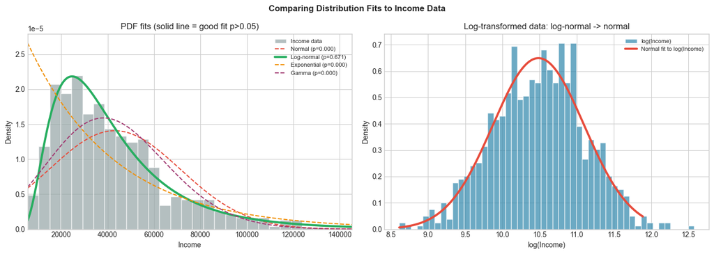

```
After log-transforming, the data looks Normal -> confirms Log-normal is the right model.
```

```python
# Visualise all fits
x_range = np.linspace(income_sample.min(), np.percentile(income_sample, 99), 400)

fig, axes = plt.subplots(1, 2, figsize=(14, 5))
fig.suptitle('Comparing Distribution Fits to Income Data', fontsize=12, fontweight='bold')

# Left: PDF comparison
axes[0].hist(income_sample, bins=60, density=True, color=COLORS['neutral'],
             edgecolor='white', alpha=0.7, label='Income data')

fit_colors = [COLORS['danger'], COLORS['success'], COLORS['accent'], COLORS['secondary']]
for (name, dist), color in zip(candidates.items(), fit_colors):
    params_fit, ks, pval = fit_results[name]
    fitted_pdf = dist.pdf(x_range, *params_fit)
    lw = 3 if pval > 0.05 else 1.5
    ls = '-' if pval > 0.05 else '--'
    axes[0].plot(x_range, fitted_pdf, color=color, lw=lw, linestyle=ls,
                 label=f'{name} (p={pval:.3f})')

axes[0].set_xlim(x_range[0], x_range[-1])
axes[0].set_xlabel('Income')
axes[0].set_ylabel('Density')
axes[0].set_title('PDF fits (solid line = good fit p>0.05)')
axes[0].legend(fontsize=8)

# Right: log-scale x-axis to see shape better
axes[1].hist(np.log(income_sample), bins=50, density=True,
             color=COLORS['primary'], edgecolor='white', alpha=0.7,
             label='log(Income)')
# After log-transform, log-normal becomes normal
ln_mu_fit, ln_sigma_fit = np.mean(np.log(income_sample)), np.std(np.log(income_sample), ddof=1)
x_log = np.linspace(np.log(income_sample.min()), np.log(np.percentile(income_sample,99)), 400)
axes[1].plot(x_log, stats.norm.pdf(x_log, ln_mu_fit, ln_sigma_fit),
             color=COLORS['danger'], lw=3, label='Normal fit to log(Income)')
axes[1].set_xlabel('log(Income)')
axes[1].set_ylabel('Density')
axes[1].set_title('Log-transformed data: log-normal -> normal')
axes[1].legend(fontsize=8)

plt.tight_layout()
plt.show()
print('After log-transforming, the data looks Normal -> confirms Log-normal is the right model.')
```

## Part 7: Q-Q Plots — The Visual Normality Test

A Quantile-Quantile (Q-Q) plot compares the **empirical quantiles** of your data against the **theoretical quantiles** of a reference distribution.

### How to read a Q-Q plot:

- **Points on the diagonal line** → data matches the reference distribution
- **S-curve** → heavier tails than reference (kurtosis)
- **Curve bending up** at the right → right skewness
- **Outliers at corners** → extreme values beyond what the distribution predicts

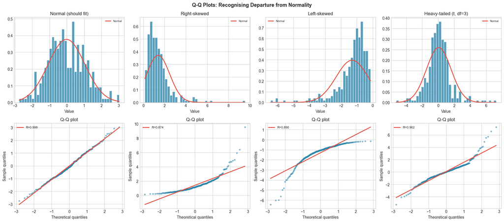

```
Reading guide:
  Normal       : points follow the line closely -> confirms normality
  Right-skewed : upper end curves UP above the line -> right heavy tail
  Left-skewed  : lower end curves DOWN below the line -> left heavy tail
  Heavy-tailed : both ends bend away from the line -> fat tails (S-curve)
```

```python
# Four datasets with different shapes
datasets = {
    'Normal (should fit)':    RNG.normal(0, 1, 300),
    'Right-skewed':           RNG.lognormal(0, 0.7, 300),
    'Left-skewed':            -RNG.lognormal(0, 0.7, 300),
    'Heavy-tailed (t, df=3)': RNG.standard_t(df=3, size=300),
}

fig, axes = plt.subplots(2, 4, figsize=(18, 8))
fig.suptitle('Q-Q Plots: Recognising Departure from Normality', fontsize=13, fontweight='bold')

for col, (name, data) in enumerate(datasets.items()):
    # Top row: histogram
    ax_hist = axes[0, col]
    ax_hist.hist(data, bins=40, color=COLORS['primary'], edgecolor='white',
                 alpha=0.8, density=True)
    x_r = np.linspace(data.min(), data.max(), 200)
    ax_hist.plot(x_r, stats.norm.pdf(x_r, data.mean(), data.std(ddof=1)),
                 color=COLORS['danger'], lw=2, label='Normal')
    ax_hist.set_title(f'{name}')
    ax_hist.set_xlabel('Value')
    ax_hist.legend(fontsize=7)

    # Bottom row: Q-Q plot
    ax_qq = axes[1, col]
    (osm, osr), (slope, intercept, r) = stats.probplot(data, dist='norm', fit=True)
    ax_qq.scatter(osm, osr, s=10, alpha=0.5, color=COLORS['primary'])
    # Reference line
    x_line = np.array([min(osm), max(osm)])
    ax_qq.plot(x_line, slope * x_line + intercept,
               color=COLORS['danger'], lw=2, label=f'R={r:.3f}')
    ax_qq.set_xlabel('Theoretical quantiles')
    ax_qq.set_ylabel('Sample quantiles')
    ax_qq.set_title('Q-Q plot')
    ax_qq.legend(fontsize=8)

plt.tight_layout()
plt.show()

print('Reading guide:')
print('  Normal       : points follow the line closely -> confirms normality')
print('  Right-skewed : upper end curves UP above the line -> right heavy tail')
print('  Left-skewed  : lower end curves DOWN below the line -> left heavy tail')
print('  Heavy-tailed : both ends bend away from the line -> fat tails (S-curve)')
```

## Part 8: Formal Goodness-of-Fit Tests

Visual inspection (histogram, Q-Q plot) should always come first. But formal tests give you a **p-value** for the "is this distribution plausible?" question.

| Test | Null hypothesis | Best used for |
| --- | --- | --- |
| **Shapiro-Wilk** | Data is normal | Small to medium samples (n < 5000) — most powerful |
| **Kolmogorov-Smirnov** | Data matches specified distribution | Any distribution; less powerful than S-W |
| **Anderson-Darling** | Data matches specified distribution | Better than KS for tails |

> **Important caveat:** with large n, these tests will reject normality for tiny, practically irrelevant deviations. Always look at the Q-Q plot alongside the p-value.

```python
# Demonstrate: Shapiro-Wilk on normal vs non-normal data, various n
print('=== Shapiro-Wilk Normality Test ===')
print()
print(f'  {"Dataset":<28}  {"n":>5}  {"W statistic":>12}  {"p-value":>10}  {"Reject H0?"}')
print('  ' + '-'*75)

test_cases = [
    ('Normal(0,1)',              lambda n: RNG.normal(0, 1, n)),
    ('t(df=5) — slightly fat',  lambda n: RNG.standard_t(df=5, size=n)),
    ('Log-normal — skewed',     lambda n: RNG.lognormal(0, 0.5, n)),
    ('Uniform(0,1)',             lambda n: RNG.uniform(0, 1, n)),
]

for n in [50, 200, 1000]:
    if n > 50:
        print()
    for name, gen in test_cases:
        data = gen(n)
        w, p = stats.shapiro(data)
        reject = 'YES  <--' if p < 0.05 else 'no'
        print(f'  {name:<28}  {n:>5}  {w:>12.6f}  {p:>10.4f}  {reject}')
```

```
=== Shapiro-Wilk Normality Test ===

  Dataset                           n   W statistic     p-value  Reject H0?
  ---------------------------------------------------------------------------
  Normal(0,1)                      50      0.975874      0.3938  no
  t(df=5) — slightly fat           50      0.892827      0.0003  YES  <--
  Log-normal — skewed              50      0.768727      0.0000  YES  <--
  Uniform(0,1)                     50      0.931658      0.0064  YES  <--

  Normal(0,1)                     200      0.988896      0.1227  no
  t(df=5) — slightly fat          200      0.970659      0.0003  YES  <--
  Log-normal — skewed             200      0.891877      0.0000  YES  <--
  Uniform(0,1)                    200      0.952693      0.0000  YES  <--

  Normal(0,1)                    1000      0.999136      0.9335  no
  t(df=5) — slightly fat         1000      0.975029      0.0000  YES  <--
  Log-normal — skewed            1000      0.889791      0.0000  YES  <--
  Uniform(0,1)                   1000      0.954129      0.0000  YES  <--
```

```python
# The large-n caveat: tiny deviation from normality gets flagged
print('=== Large-n caveat: practical vs statistical significance ===')
print()
print('  Generating Normal(0,1) data with a tiny skewness perturbation (0.02)...')
print()

for n in [100, 1000, 5000, 20000, 100000]:
    # Add a tiny perturbation: slightly skew the data
    base = RNG.normal(0, 1, n)
    perturbed = base + 0.02 * base**2  # tiny non-linearity
    w, p = stats.shapiro(min(perturbed, key=None) if n > 5000 else perturbed[:5000])
    w2, p2 = stats.shapiro(perturbed[:min(n, 5000)])  # SW limited to 5000
    _, ks_p = stats.kstest(perturbed, 'norm', args=(perturbed.mean(), perturbed.std(ddof=1)))
    skew_val = stats.skew(perturbed)
    print(f'  n={n:>7,}  skewness={skew_val:.4f}  SW: p={p2:.4f}  KS: p={ks_p:.6f}  '
          f'SW_reject={"YES" if p2<0.05 else "no"}')

print()
print('Lesson: At n=100,000, even a skewness of 0.04 yields p<0.05.')
print('Always ask: "Is this deviation practically meaningful?" not just "Is p<0.05?"')
```

[output not shown]

## Part 9: Choosing the Right Distribution — A Decision Guide

| Your variable | Typical distribution(s) | Key check |
| --- | --- | --- |
| Continuous, symmetric, no bounds | **Normal** | Q-Q plot, Shapiro-Wilk |
| Continuous, strictly positive, right-skewed | **Log-normal** or **Gamma** | Log-transform -> Normal? |
| Continuous, bounded [0,1] (proportions) | **Beta** | values clamped to [0,1]? |
| Continuous, time until event | **Exponential** or **Weibull** | Memoryless? |
| Count of events in interval | **Poisson** | Mean ≈ Variance? |
| Count of successes in n trials | **Binomial** | Fixed n, binary outcome? |
| Count with overdispersion (var >> mean) | **Negative Binomial** | Variance >> Mean? |
| Ordinal or bounded integer | **Ordered Logit** / **Multinomial** | Ordinal scale? |

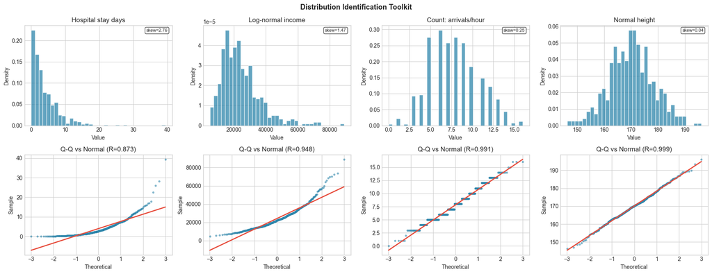

```
Diagnostics summary:
  Hospital stay days         skew=+2.76  SW_p=0.0000  mean/var=0.222  -> True dist: Exp
  Log-normal income          skew=+1.47  SW_p=0.0000  mean/var=0.000  -> True dist: LogN
  Count: arrivals/hour       skew=+0.25  SW_p=0.0000  mean/var=0.929  -> True dist: Pois
  Normal height              skew=+0.04  SW_p=0.8142  mean/var=2.508  -> True dist: Normal
```

```python
# Decision tree simulation: generate data from 4 different processes,
# then use diagnostics to identify the right distribution

fig, axes = plt.subplots(2, 4, figsize=(18, 7))
fig.suptitle('Distribution Identification Toolkit', fontsize=13, fontweight='bold')

scenarios = [
    ('Hospital stay days',      RNG.exponential(scale=4, size=500),     stats.expon,   'Exp'),
    ('Log-normal income',       RNG.lognormal(10, 0.5, size=500),       stats.lognorm, 'LogN'),
    ('Count: arrivals/hour',    RNG.poisson(lam=8, size=500).astype(float), stats.poisson, 'Pois'),
    ('Normal height',           RNG.normal(170, 8, size=500),           stats.norm,    'Normal'),
]

for col, (name, data, true_dist, dist_label) in enumerate(scenarios):
    # Row 0: histogram
    ax_h = axes[0, col]
    ax_h.hist(data, bins=35, density=True, color=COLORS['primary'],
              edgecolor='white', alpha=0.75)
    ax_h.set_title(f'{name}')
    ax_h.set_xlabel('Value')
    ax_h.set_ylabel('Density')

    # Summary diagnostics
    skew_v = stats.skew(data)
    kurt_v = stats.kurtosis(data)
    ax_h.text(0.97, 0.97, f'skew={skew_v:.2f}',
              transform=ax_h.transAxes, ha='right', va='top', fontsize=8,
              bbox=dict(boxstyle='round', fc='white', alpha=0.7))

    # Row 1: Q-Q plot against Normal
    ax_q = axes[1, col]
    (osm, osr), (slope, intercept, r) = stats.probplot(data, dist='norm', fit=True)
    ax_q.scatter(osm, osr, s=8, alpha=0.5, color=COLORS['primary'])
    x_qq = np.array([osm.min(), osm.max()])
    ax_q.plot(x_qq, slope*x_qq + intercept, color=COLORS['danger'], lw=2)
    ax_q.set_title(f'Q-Q vs Normal (R={r:.3f})')
    ax_q.set_xlabel('Theoretical')
    ax_q.set_ylabel('Sample')

plt.tight_layout()
plt.show()

print('Diagnostics summary:')
for name, data, _, label in scenarios:
    sw_stat, sw_p = stats.shapiro(data[:min(500, len(data))])
    skew_v        = stats.skew(data)
    mv_ratio      = data.mean() / data.var(ddof=1) if data.var(ddof=1) > 0 else np.nan
    print(f'  {name:<25}  skew={skew_v:+.2f}  SW_p={sw_p:.4f}  mean/var={mv_ratio:.3f}  -> True dist: {label}')
```

## Part 10: First Look at the Central Limit Theorem

The Central Limit Theorem (CLT) is perhaps the most powerful result in statistics:

> **CLT:** As $n \to \infty$, the sample mean $\bar{X}_n = \frac{1}{n}\sum_{i=1}^n X_i$ converges in distribution to $N(\mu, \sigma^2/n)$, **regardless of the shape of the population distribution**.

This is why normal-based methods (t-tests, confidence intervals) work even when the underlying data is not perfectly normal — as long as $n$ is large enough.

### Rule of thumb: $n \ge 30$ is usually sufficient for CLT to kick in for moderately skewed data.

We will explore CLT in depth in Lecture 04. Here we preview the key simulation.

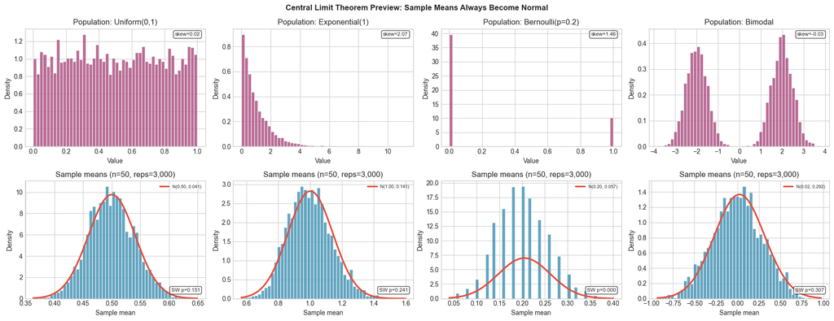

[output not shown]

```python
# Demonstrate CLT: sample means from highly non-normal populations
fig, axes = plt.subplots(2, 4, figsize=(18, 7))
fig.suptitle('Central Limit Theorem Preview: Sample Means Always Become Normal', fontsize=12, fontweight='bold')

populations = [
    ('Uniform(0,1)',      lambda n: RNG.uniform(0, 1, n)),
    ('Exponential(1)',    lambda n: RNG.exponential(1, n)),
    ('Bernoulli(p=0.2)',  lambda n: RNG.binomial(1, 0.2, n).astype(float)),
    ('Bimodal',           lambda n: np.where(RNG.uniform(0,1,n)<0.5, RNG.normal(-2,0.5,n), RNG.normal(2,0.5,n))),
]
N_REPS  = 3000
N_SAMPLE = 50

for col, (name, gen) in enumerate(populations):
    # Row 0: population distribution
    pop = gen(5000)
    axes[0, col].hist(pop, bins=50, density=True, color=COLORS['secondary'],
                      edgecolor='white', alpha=0.75)
    axes[0, col].set_title(f'Population: {name}')
    axes[0, col].set_xlabel('Value')
    axes[0, col].set_ylabel('Density')
    skew_v = stats.skew(pop)
    axes[0, col].text(0.97, 0.97, f'skew={skew_v:.2f}',
                      transform=axes[0, col].transAxes, ha='right', va='top', fontsize=8,
                      bbox=dict(boxstyle='round', fc='white', alpha=0.7))

    # Row 1: sampling distribution of the mean (n=50)
    sample_means = [gen(N_SAMPLE).mean() for _ in range(N_REPS)]
    sm = np.array(sample_means)
    axes[1, col].hist(sm, bins=50, density=True, color=COLORS['primary'],
                      edgecolor='white', alpha=0.75)
    # Overlay expected normal distribution
    expected_mu    = pop.mean()
    expected_sigma = pop.std(ddof=1) / np.sqrt(N_SAMPLE)
    x_range = np.linspace(sm.min(), sm.max(), 200)
    axes[1, col].plot(x_range, stats.norm.pdf(x_range, expected_mu, expected_sigma),
                      color=COLORS['danger'], lw=2.5, label=f'N({expected_mu:.2f}, {expected_sigma:.3f})')
    axes[1, col].set_title(f'Sample means (n={N_SAMPLE}, reps={N_REPS:,})')
    axes[1, col].set_xlabel('Sample mean')
    axes[1, col].set_ylabel('Density')
    axes[1, col].legend(fontsize=7)
    sw_stat, sw_p = stats.shapiro(sm[:500])
    axes[1, col].text(0.97, 0.05, f'SW p={sw_p:.3f}',
                      transform=axes[1, col].transAxes, ha='right', va='bottom',
                      fontsize=8, bbox=dict(boxstyle='round', fc='white', alpha=0.7))

plt.tight_layout()
plt.show()

print('Even when the population is highly non-normal, sample means (n=50) are well-approximated')
print('by a Normal distribution — this is the Central Limit Theorem in action.')
```

## Summary

| Concept | Key takeaway |
| --- | --- |
| PDF, CDF, quantile | Three equivalent views of any distribution |
| 68-95-99.7 rule | Verified by simulation; true for all Normal$(\mu, \sigma)$ |
| z-score | Standardises any normal to $N(0,1)$; unlocks shared tables |
| Binomial | Count of successes; $\to$ Poisson when $n$ large, $p$ small |
| Poisson | Count of rare events; mean = variance is a diagnostic |
| t-distribution | Heavier tails than Normal; $\to$ Normal as df $\to \infty$ |
| Distribution fitting | `scipy.stats.dist.fit()` + KS test for goodness of fit |
| Q-Q plot | Visual normality test; S-curve = fat tails; bend = skew |
| Shapiro-Wilk | Most powerful normality test; inflated at large $n$ |
| CLT preview | Sample means always become Normal as $n$ grows |

### Distribution Identification Checklist

```
1. Is the variable discrete (counts) or continuous?
2. Continuous:
   a. Is it bounded below at 0? → Log-normal, Gamma, Exponential, Weibull
   b. Is it bounded in [0,1]? → Beta
   c. Symmetric, unbounded? → Normal (check Q-Q plot)
3. Discrete:
   a. Count of events per interval? → Poisson (check mean ≈ variance)
   b. Count of successes in n trials? → Binomial
   c. Count with overdispersion? → Negative Binomial
```

**Next lecture →** Lecture 04: The Central Limit Theorem in Action — why it works, when it fails, and how it justifies many statistical tests.

*Python Statistical Analysis in Practice — Lecture 03*  
*Author: Jason JJ Li · PKU Institute of Population Research*